# R Notebook

# Aufgabe 7: Wilcoxon-Test

# Aufgabenstellung

## Beschreibung:

Studentenwohnheim “Haus der Unordnung” möchte herausfinden, ob die Toleranzschwellwert gegenüber unhygienischen Zuständen(TUZ) sich im Lauf des Studiums ändern. Daher wird der Toleranzschwellwert gegenüber unhygienischen Zuständen vor dem Einzug und drei Jahren nach dem Einzug ins Wohnheim erhoben. Je höher der TUZ-Wert, desto höher der Toleranz-Schwellwert gegen Schmutz.

## Daten:

Variable1: TUZ vorher Varibale2: TUZ nachher

## 1. Hypothese:

H1: Es gibt einen Unterschied in den Toleranzschwellwert gegenüber unhygienischen Zuständen vor dem Einzug und drei Jahren nach dem Einzug ins Wohnheim. MEvorher≠MEnacher

H0: Es gibt keinen Unterschied in den Toleranzschwellwert gegenüber unhygienischen Zuständen vor dem Einzug und drei Jahren nach dem Einzug ins Wohnheim. MEvorher=MEnachher

## 2. Voraussetzungen für den Wilcoxon-Test:

Die abhängige Variable ist mindestens ordinalskaliert -> Die Variable ist eigentlich metrisch.

Es liegen zwei verbundene Stichproben oder Gruppen vor, aber die verschiedenen Messwertpaare sind voneinander unabhängig - 1) Verbunden, weil wir den gleichen Studenten pro Zeile vergleichen 2) z.B Student A und Student B sind unabhängig.

### Boxplots zur Darstellung der Werte:

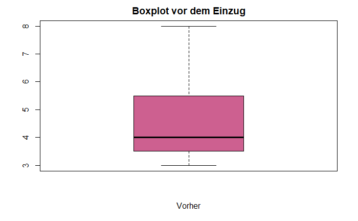

```r
wilcoxen <- uebung7
wilcoxen$Vorher <- wilcoxen$`TUZ vorher`
wilcoxen$Nachher <- wilcoxen$`TUZ nachher`
boxplot(wilcoxen$Vorher, main = "Boxplot vor dem Einzug", xlab = "Vorher", col = "hotpink3")
```

Vor dem Einzug zeigt sich, dass keine Ausreißer auftraten (Median = 4).

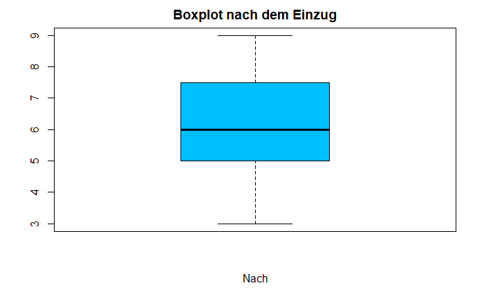

```r
boxplot(wilcoxen$Nachher, main = "Boxplot nach dem Einzug", xlab = "Nach", col = "deepskyblue")
```

Nach dem Einzug zeigt sich, dass keine Ausreißer auftraten (Median = 6).

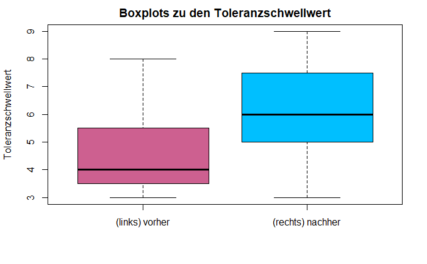

```r
boxplot(wilcoxen$Vorher, wilcoxen$Nachher, main = "Boxplots zu den Toleranzschwellwert", col = c("hotpink3", "deepskyblue"), names = c("(links) vorher", "(rechts) nachher"), ylab = "Toleranzschwellwert")
```

Es gibt keine Ausreißer und die Daten sehen gut verteilt aus.

### Berechnung der Mediane:

```r
library(psych)
zusammenfassung <-describe(wilcoxen)
zusammenfassung
```

|  | vars | n | mean | sd | median | trimmed | mad | min | max | range | skew | kurtosis | se |
| --- | --- | --- | --- | --- | --- | --- | --- | --- | --- | --- | --- | --- | --- |
| ID | 1 | 12 | 6.50 | 3.61 | 6.5 | 6.5 | 4.45 | 1 | 12 | 11 | 0.00 | -1.50 | 1.04 |
| TUZ vorher | 2 | 12 | 4.67 | 1.61 | 4.0 | 4.5 | 1.48 | 3 | 8 | 5 | 0.74 | -0.79 | 0.47 |
| TUZ nachher | 3 | 12 | 6.17 | 1.90 | 6.0 | 6.2 | 1.48 | 3 | 9 | 6 | 0.07 | -1.27 | 0.55 |
| Vorher | 4 | 12 | 4.67 | 1.61 | 4.0 | 4.5 | 1.48 | 3 | 8 | 5 | 0.74 | -0.79 | 0.47 |
| Nachher | 5 | 12 | 6.17 | 1.90 | 6.0 | 6.2 | 1.48 | 3 | 9 | 6 | 0.07 | -1.27 | 0.55 |

### ALTERNATIV:

#### Median der Var. Vorher und Nachher:

```r
sprintf("Median für Vor dem Rabatt : %.2f", median(wilcoxen$Vorher))
```

```
[1] "Median für Vor dem Rabatt : 4.00"
```

```r
sprintf("Median für Nach dem Rabatt : %.2f", median(wilcoxen$Nachher))
```

```
[1] "Median für Nach dem Rabatt : 6.00"
```

```r
sprintf("Anzahl der Daten: %.f", nrow(wilcoxen))
```

```
[1] "Anzahl der Daten: 12"
```

Es gibt einen Unterschied in der zentralen Tendenz zwischen zwei Messzeitpunkten.Vor dem Einzug liegt die Toleranzschwelle bei einem Median von 4 und nach 3 Jahren nach dem Einzug bei 6 (n=12).

## 3. Grundlegende Konzepte:

Der Wilcoxon-Test – auch Wilcoxon-Vorzeichen-Rang-Test genannt (engl. “Wilcoxon signed-rank test”, kurz WSR) – für abhängige Stichproben testet, ob die zentralen Tendenzen zweier abhängiger Stichproben verschieden sind. Der Wilcoxon-Test wird verwendet, wenn die Voraussetzungen für einen t-Test für abhängige Stichproben nicht erfüllt sind.

## 4. Ergebnisse des Wilcoxon-Tests:

Ist die Stichprobe hinreichend gross (n > 20), so ist der kritische Wert asymptotisch normalverteilt.

```r
test<- wilcox.test(wilcoxen$Vorher, wilcoxen$Nachher,alternative = "two.sided",paired = TRUE, exact = FALSE)
test
```

```
    Wilcoxon signed rank test with continuity correction

data:  wilcoxen$Vorher and wilcoxen$Nachher
V = 2, p-value = 0.009628
alternative hypothesis: true location shift is not equal to 0
```

### Ist dies nicht der Fall, so wird die exakte Signifikanz verwendet.

```r
test<- wilcox.test(wilcoxen$Vorher, wilcoxen$Nachher,alternative = "two.sided",paired = TRUE, exact = TRUE)
```

```
cannot compute exact p-value with tiescannot compute exact p-value with zeroes
```

```r
test
```

```
    Wilcoxon signed rank test with continuity correction

data:  wilcoxen$Vorher and wilcoxen$Nachher
V = 2, p-value = 0.009628
alternative hypothesis: true location shift is not equal to 0
```

#### doppelt vorkommende Daten

“kann bei Bindungen keinen exakten p-Wert Berechnenkann den exakten p-Wert bei Nullen nicht berechnen”- Da in diesem Datensatz die Rangierung doppelt vorkommen, kann kein exakter p-Wert berechnet werden.

#### Exakter Test wegen sehr kleiner Stichprobe n=12

```r
library(exactRankTests)
test<- wilcox.exact(wilcoxen$Vorher, wilcoxen$Nachher,alternative = "two.sided",paired = TRUE, exact = TRUE)
test
```

```
    Exact Wilcoxon signed rank test

data:  wilcoxen$Vorher and wilcoxen$Nachher
V = 2, p-value = 0.007812
alternative hypothesis: true mu is not equal to 0
```

Die Teststatistik beträgt V = 2 und der zugehörige Signifikanzwert p = .007. Damit ist der Unterschied signifikant: Die zentralen Tendenzen der beiden Messzeitpunkte unterscheiden sich (Wilcoxon-Test: V = 2, p = .007, n = 12).

## 5. Berechnung der Effektstärke:

$$r=\left| \frac{z}{\sqrt{n}} \right|$$

Der z - Wert

```r
Zstat1<-qnorm(test$p.value/2)

sprintf("Z-Wert für den WSR: %.2f", Zstat1)
```

```
[1] "Z-Wert für den WSR: -2.66"
```

```r
nk<-nrow(wilcoxen[wilcoxen$Vorher!=wilcoxen$Nachher,])
sprintf("Anzahl ohne Null: %.f", nk)
```

```
[1] "Anzahl ohne Null: 10"
```

Die Anzahl kann auch unter Datenmatrix ausgelesen werden. In dem vorliegenden Beispiel sind es 10 Datensätze.

```r
eff <-abs(Zstat1)/sqrt(nk)
sprintf("Effektstärke: %.2f", eff)
```

```
[1] "Effektstärke: 0.84"
```

Zur Beurteilung der Grösse des Effektes dient die Einteilung von Cohen (1988):

$$\begin{align}
\text{Schwacher Effekt: } 0.10 &< ||r|| < 0.25 \\
\text{Schwacher bis mittlerer Effekt: } 0.25 &= ||r|| \\
\text{Mittlerer Effekt: } 0.25 &< ||r|| < 0.40 \\
\text{Mittlerer bis starker Effekt: }0.40 &= ||r|| \\
\text{Starker Effekt: } 0.40 &< ||r||
\end{align}$$

Damit entspricht die Effektstärke von .84 einem starken Effekt.

## 6. Eine Aussage:

Die Toleranzschwelle steigt nach 3 Jahren im Wohnheim an (V = 2, p-value = 0.007812, n=12). Beim Einzug liegt der Median für die Toleranz gegen Schutz und Dreck bei 4 nach 3 Jahren bei 6, sprich die Studierenden werden toleranter gegenüber Schmutz und Dreck. Die Effektstärke nach Cohen (1988) liegt bei r = .84 und entspricht einem starken Effekt.

H0 kann verworfen werden.